# Tobacco Census 2025

Author

Moses Fleischman

**Aims of this report**

This report seeks to describe the 2025 CIFTR data in greater detail and clarify the methods by which analyses and visualizations were created. It is meant to be reviewed after viewing the primary material.

# About the Data

## Survey Design and Collection

This survey is a long running audit of all of the stores, restaurants, bars, and other establishments in the city of Cleveland. It aims to collect information on the accessibility to a variety of products, including healthy foods, as well as drugs and tobacco.

The information on these establishments is collected annually during the summer by a team of volunteers. The details are collected primarily via groundtruthing.

| How was the status of this store determined? (choice=Groundtruthing) | n |
| --- | --- |
| Checked | 2443 |
| Unchecked | 9 |

For more information on the methods of this study, please visit: *http://prchn.org/ciftr/*.

On account of the survey being long running, it contains a multitude of establishments that have since closed or changed property type. As of the summer of 2025, the data contains 699 closed establishments and 1753 currently open establishments.

| Open | n |
| --- | --- |
| No | 699 |
| Yes | 1753 |

This summary of open establishments can be divided by establishment type, as seen below.

| 2022 Classification, based on Store type (using Oct 2020 classification system) | n |
| --- | --- |
| Bar/Lounge | 11 |
| Corner/Convenience Store | 418 |
| Dine-in Restaurant | 28 |
| Fast food or take out | 1028 |
| Food not sold at this location yet | 4 |
| Large Grocery Store | 23 |
| Liquor Store | 13 |
| Small Grocery Store | 61 |
| Specialty Store | 4 |
| Supermarket | 13 |
| Temporarily Closed | 38 |
| Tobacco Store | 3 |

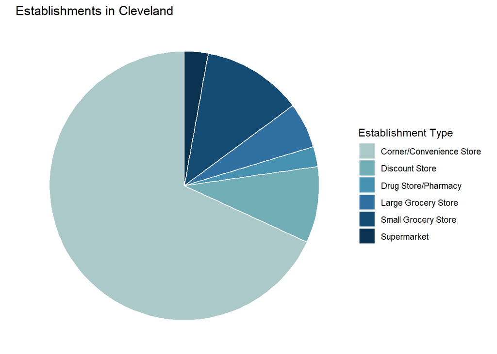

The above pie chart contains less establishments than the table above, the reason for this is described in the next section.

# Tobacco Sales

Establishments that sold tobacco products were counted and are displayed below. Tobacco products considered include the following:

- Cigarettes
- Menthol cigarettes
- ENDS (e-cigarettes)
- Cigarillos/Little Cigars
- Nicotine Pouches
- Roll-Your-Own Tobacco

The following establishments are omitted from this list, as described previously:

- Restaurants (Full-service and Limited-service/Fast-food)
- Bars and Liquor Stores
- Closed Stores/Restaurants
- Tobacco/Smoking Suppliers

In order to do this, we define a new variable `has_tobacco`, which is a binary variable, in which 1 means the establishment in question has one of the above defined products.

Then, because this report is concerned primarily with easily accessible sources of tobacco, certain establishments are removed. Closed establishments were removed, along with restaurants and bars, as well as tobacco suppliers (in part due to some of those tasked with auditing in 2025 were under the age of 21). Stores that seemed to primarily sell tobacco (based on signage for a smoke or e-cigarette shop, or other exterior signs) were not further investigated, and simply assumed to carry some form of tobacco or another.

Using our data set we can establish a table with the number of each type of establishment that sells tobacco and calculate a proportion that sell tobacco.

| has_tobacco | n |
| --- | --- |
| 0 | 85 |
| 1 | 373 |

| Establishment Type | Tobacco not sold | Tobacco sold | Proportion |
| --- | --- | --- | --- |
| Corner/Convenience Store | 28 | 284 | 0.910 |
| Discount Store | 9 | 33 | 0.786 |
| Drug Store/Pharmacy | 7 | 4 | 0.364 |
| Large Grocery Store | 17 | 8 | 0.320 |
| Small Grocery Store | 20 | 35 | 0.636 |
| Supermarket | 4 | 9 | 0.692 |

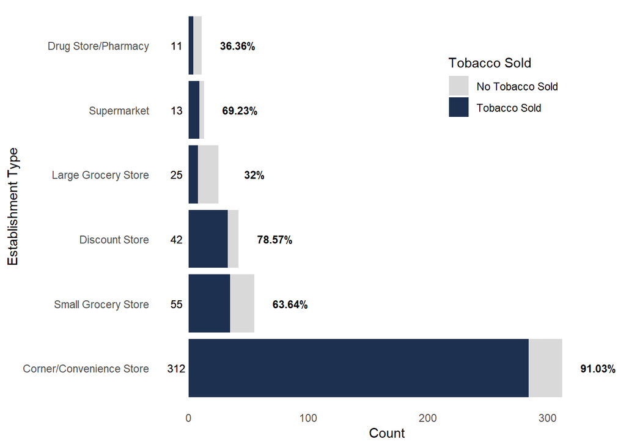

**Corner/Convenience Store**

| Retail Name | Unique Street Address | Establishment Type | has_tobacco |
| --- | --- | --- | --- |
| Edgewater Delicatessen | 8701 Lake | Corner/Convenience Store | 1 |
| Dairy Mart #5447 | 8808 Detroit | Corner/Convenience Store | 1 |
| E-Z Shop | 11521 Clifton | Corner/Convenience Store | 1 |
| Baltic & Clifton Shell | 9510 Baltic | Corner/Convenience Store | 1 |
| Constantino's | 11022 Clifton | Corner/Convenience Store | 1 |
| Express Gas (D & R Express) | 7704 Detroit | Corner/Convenience Store | 1 |
| Deli | 11006 Detroit | Corner/Convenience Store | 1 |
| Fred's Deli | 11119 Detroit | Corner/Convenience Store | 1 |
| Corner Stop | 11026 Lorain | Corner/Convenience Store | 1 |
| Gabriel's Shell | 2249 W. 117th | Corner/Convenience Store | 1 |
| Frank's Tackle Co. | 10802 Madison | Corner/Convenience Store | 1 |
| Tienda Central Hispana | 11210 Lorain | Corner/Convenience Store | 0 |
| Unimart (Inside BP) | 3065 W. 117th | Corner/Convenience Store | 1 |
| Express Food Mart | 10134 Madison | Corner/Convenience Store | 1 |
| BP Uni-Mart | 10202 Lorain | Corner/Convenience Store | 1 |
| Midway Market | 2136 W. 98th | Corner/Convenience Store | 1 |
| Madison 89 Deli | 8901 Madison | Corner/Convenience Store | 1 |
| HP Gas | 7310 Lorain | Corner/Convenience Store | 1 |
| A and F Food Market | 2044 W. 65th | Corner/Convenience Store | 1 |
| Cita African Store | 6500 Lorain Ave | Corner/Convenience Store | 0 |
| Mega Mart | 3519 W. 117th | Corner/Convenience Store | 1 |
| Gasway | 10606 Bellaire | Corner/Convenience Store | 1 |
| Convenient Food Mart | 3584 W. 105th | Corner/Convenience Store | 1 |
| Exbo | 11622 Bellaire | Corner/Convenience Store | 1 |
| Steve's Deli | 3590 Bosworth | Corner/Convenience Store | 1 |
| West Town Village Market | 3645 W. 117th | Corner/Convenience Store | 1 |
| Q's Gas n' Go | 3585 W. 117th | Corner/Convenience Store | 1 |
| Star Value | 3691 W. 105th | Corner/Convenience Store | 1 |
| S & R Market One Stop Shop | 9901 Loretta | Corner/Convenience Store | 1 |
| Tienda GuateOhio | 9713 Denison | Corner/Convenience Store | 0 |

[output cut: 282 more lines]

**Small Grocery Store**

| Retail Name | Unique Street Address | Establishment Type | has_tobacco |
| --- | --- | --- | --- |
| Middle Eastern Imports / Halal Meats | 9418 Detroit | Small Grocery Store | 0 |
| GFS | 1363 W. 117th | Small Grocery Store | 0 |
| Almadina Imported Foods | 11550 Lorain | Small Grocery Store | 1 |
| Madison West Side Market | 9815 Madison | Small Grocery Store | 1 |
| Tienda Guatamala | 10108 Lorain | Small Grocery Store | 0 |
| Alexanderia Market | 7602 Madison | Small Grocery Store | 1 |
| The Deli | 7380 Franklin | Small Grocery Store | 1 |
| Linda's Beverage & Deli | 8708 Denison | Small Grocery Store | 1 |
| Save-A-Lot | 5901 Detroit | Small Grocery Store | 0 |
| Kolou's Marketplace | 4700 Bridge Ave | Small Grocery Store | 0 |
| La Borincana | 2127 Fulton | Small Grocery Store | 0 |
| Tony's Market State Liquor Store | 3114 Clark | Small Grocery Store | 1 |
| Suleyman's Supermarket | 3121 Marvin | Small Grocery Store | 1 |
| Fulton Beverage | 3335 Fulton | Small Grocery Store | 1 |
| Sav-Way Food Mart | 4926 Denison | Small Grocery Store | 1 |
| Quick Shop Food Mart | 4053 Marvin | Small Grocery Store | 1 |
| Convience Store on Storer | 4701 Storer | Small Grocery Store | 1 |
| Athens Pastries and Imported Fod | 5120 Pearl | Small Grocery Store | 0 |
| Convenient Food Mart | 4828 State | Small Grocery Store | 1 |
| City Food | 1810 E. 12th | Small Grocery Store | 1 |
| Downtown Beverage | 1283 E. 17th | Small Grocery Store | 1 |
| DGX Cleveland | 1701E E. 12th St. | Small Grocery Store | 1 |
| Simply Food | 1701D E 12th St. | Small Grocery Store | 1 |
| Tink Holl Enterprises Inc. | 1735A E. 36th | Small Grocery Store | 0 |
| PARK N' SHOP | 1580 E. 30th | Small Grocery Store | 1 |
| PAUL'S SERVE RITE FOOD MARKET | 4621 CENTRAL | Small Grocery Store | 1 |
| Square Deal State Liquor | 2747 Cedar | Small Grocery Store | 1 |
| Sheliga Drug | 6025 St. Clair | Small Grocery Store | 1 |
| Prime Meats | 7710 Superior | Small Grocery Store | 0 |
| Rumi's Restaurant and Deli | 8225 Carnegie | Small Grocery Store | 0 |
| Farm House Food Distributors, Inc. | 9000 Woodland | Small Grocery Store | 0 |
| Save-A-Lot | 5841 Broadway | Small Grocery Store | 0 |
| Slavic Village Market | 6405 Fleet | Small Grocery Store | 1 |
| Dollar General #11392 | 6815 Broadway | Small Grocery Store | 1 |
| P.N.G. Food Market | 4324 Warner | Small Grocery Store | 1 |
| The New Eastside Market | 10505 St. Clair Ave. | Small Grocery Store | 1 |
| Family Dollar Store | 10390 St. Clair | Small Grocery Store | 1 |
| Save-A-Lot | 12432 St. Clair | Small Grocery Store | 0 |
| Family Foods | 1010 E. 152nd | Small Grocery Store | 1 |
| Dollar General | 15707 St. Clair | Small Grocery Store | 1 |
| Save-A-Lot | 11905 Superior | Small Grocery Store | 0 |
| Constantino's | 11473 Euclid | Small Grocery Store | 0 |
| Unity Food Market | 10221 Union | Small Grocery Store | 1 |
| Prime Meats | 3935 E. 131st | Small Grocery Store | 0 |
| Dollar General | 3785 Lee Rd | Small Grocery Store | 1 |
| La Plaza Supermarket | 13609 Lakewood Heights | Small Grocery Store | 1 |
| Arabian Village Market | 12926 Lorain | Small Grocery Store | 0 |
| Mini Mart | 3778 W. 117th | Small Grocery Store | 1 |
| Holy Land Imported | 11717 Lorain | Small Grocery Store | 0 |
| Rite Shop | 14053 Lorain | Small Grocery Store | 1 |

**Discount Store**

| Retail Name | Unique Street Address | Establishment Type | has_tobacco |
| --- | --- | --- | --- |
| Family Dollar | 7301 Detroit | Discount Store | 1 |
| Family Dollar | 10820 Lorain | Discount Store | 1 |
| Family Dollar | 8404 Madison Ave. | Discount Store | 1 |
| Roses Discount Store | 3250 W. 65th | Discount Store | 0 |
| Family Dollar | 6513 Clark | Discount Store | 1 |
| Family Dollar | 1936 W. 25th | Discount Store | 1 |
| Dollar General | 3040 Fulton Rd | Discount Store | 1 |
| Family Dollar | 2704 Clark | Discount Store | 1 |
| Deals | 3379 Steelyard | Discount Store | 0 |
| Family Dollar | 3545 Ridge | Discount Store | 1 |
| Dollar Tree | 3742 Pearl | Discount Store | 0 |
| Aldi #25 | 3787 Pearl | Discount Store | 1 |
| Family Dollar #4132 | 4247 Fulton | Discount Store | 1 |
| Food Peddler Farm Market | 4250 Fulton | Discount Store | 0 |
| Family Dollar Stores 5796 | 4172 Pearl | Discount Store | 1 |
| Family Dollar #8343 | 2152 Brookpark | Discount Store | 1 |
| A Dollar | 230 W.Huron #134 | Discount Store | 0 |
| Family Dollar | 3407 Payne | Discount Store | 1 |
| Dean Supply | 3500 Woodland | Discount Store | 0 |
| Family Dollar | 7415 Superior | Discount Store | 1 |
| Family Dollar | 7965 Euclid | Discount Store | 1 |
| Discounts 'R' Us | 2549 E. 55th | Discount Store | 1 |
| Eagle Fresh Market | 7515 Kinsman | Discount Store | 1 |
| Family Dollar | 3470 E. 93rd | Discount Store | 1 |
| Dollar General | 3162 E. 91st St. | Discount Store | 1 |
| Silverman's | 6601 Harvard | Discount Store | 0 |
| Family Dollar | 12107 St. Clair | Discount Store | 1 |
| Family Dollar | 1014 E. 152nd | Discount Store | 1 |
| Family Dollar #6254 | 16122A Lakeshore | Discount Store | 1 |
| Family Dollar | 570 E 185th | Discount Store | 1 |
| Family Dollar | 12915 Buckeye | Discount Store | 1 |
| Family Dollar | 11511 Kinsman | Discount Store | 1 |
| Family Dollar | 14235 Kinsman | Discount Store | 1 |
| Kinsman Discount | 11902 Kinsman | Discount Store | 1 |
| Family Dollar | 4071B Lee #210 | Discount Store | 1 |
| Dollar Tree | 17442 Lorain | Discount Store | 0 |
| Family Dollar | 4444 Rocky River | Discount Store | 1 |
| Giant Mart | 4202 W. 130th | Discount Store | 1 |
| Family Dollar | 14035 Puritas | Discount Store | 1 |
| Family Dollar | 4576 W. 130th | Discount Store | 1 |
| Dollar Tree | 12709 Bellaire | Discount Store | 0 |
| Dollar General | 12526 Bellaire | Discount Store | 1 |

**Large Grocery Store**

| Retail Name | Unique Street Address | Establishment Type | has_tobacco |
| --- | --- | --- | --- |
| Save-A-Lot | 10950 Lorain | Large Grocery Store | 0 |
| Save-A-Lot | 3024 Clark | Large Grocery Store | 0 |
| Save-A-Lot | 2210 Brookpark | Large Grocery Store | 0 |
| TARGET STORE # 2228 | 3535A Steelyard | Large Grocery Store | 0 |
| Aldis | 3586 Steelyard | Large Grocery Store | 0 |
| Discount Drug Mart | 4170 Fulton | Large Grocery Store | 1 |
| Save-A-Lot | 4215 Fulton | Large Grocery Store | 0 |
| Save-A-Lot | 7210 Superior | Large Grocery Store | 0 |
| Aldi | 7500 Euclid | Large Grocery Store | 0 |
| Church Square Market | 7973 Euclid | Large Grocery Store | 1 |
| Save-A-Lot | 6501 Harvard | Large Grocery Store | 0 |
| Dave's Supermarket | 7422 Harvard | Large Grocery Store | 1 |
| Save-A-Lot | 18501 Neff | Large Grocery Store | 0 |
| Aldi | 18235 Euclid | Large Grocery Store | 0 |
| Save-A-Lot | 14301 Kinsman | Large Grocery Store | 0 |
| Aldi | 10815 Kinsman | Large Grocery Store | 0 |
| Miles Supermarket | 4127 E. 131st | Large Grocery Store | 1 |
| Family Dollar | 13020B Miles | Large Grocery Store | 1 |
| Marc's | 17400 Lorain | Large Grocery Store | 1 |
| Target | 3100A W. 117th St | Large Grocery Store | 0 |
| Rubin's Family Restaurant | 14651 Lorain | Large Grocery Store | 0 |
| Discount Drug Mart | 17815 Puritas | Large Grocery Store | 1 |
| Marcs | 15030 Puritas | Large Grocery Store | 1 |
| Save-A-Lot | 14041 Puritas | Large Grocery Store | 0 |
| Fairfax Market | 2190 E 105th St | Large Grocery Store | 0 |

**Drug Store/Pharmacy**

| Retail Name | Unique Street Address | Establishment Type | has_tobacco |
| --- | --- | --- | --- |
| CVS Pharmacy | 3171 West Blvd. | Drug Store/Pharmacy | 0 |
| Walgreens | 3415 Clark | Drug Store/Pharmacy | 1 |
| Walgreens 3308 | 4265 State | Drug Store/Pharmacy | 1 |
| CVS Pharmacy | 840 Euclid | Drug Store/Pharmacy | 0 |
| CVS Pharmacy | 8000 Euclid | Drug Store/Pharmacy | 0 |
| Only a Dollar | 6630A Broadway | Drug Store/Pharmacy | 0 |
| CVS Pharmacy | 6301 Harvard | Drug Store/Pharmacy | 0 |
| CVS Pharmacy | 13215 Shaker | Drug Store/Pharmacy | 0 |
| Walgreens | 4071A Lee | Drug Store/Pharmacy | 1 |
| Walgreens | 16803 Lorain | Drug Store/Pharmacy | 1 |
| CVS | 14025 Puritas | Drug Store/Pharmacy | 0 |

**Supermarket**

| Retail Name | Unique Street Address | Establishment Type | has_tobacco |
| --- | --- | --- | --- |
| Lucky's Market | 11620 Clifton | Supermarket | 0 |
| Dave's | 2700 Carroll | Supermarket | 1 |
| Wal-mart Supercenter | 3400A Steelyard | Supermarket | 0 |
| Dave's Supermarket | 3565 Ridge | Supermarket | 1 |
| Constantino's Market | 1278 W.9th | Supermarket | 0 |
| Heinen's Grocery Store | 900A Euclid | Supermarket | 0 |
| Dave's Supermarket | 1929 E. 61st | Supermarket | 1 |
| Giant Eagle | 11501 Buckeye | Supermarket | 1 |
| Dave's Supermarket | 13130 Shaker Sq | Supermarket | 1 |
| Dave's Supermarket | 16820 Harvard | Supermarket | 1 |
| Giant Eagle | 15325 Edgecliff | Supermarket | 1 |
| Giant Eagle | 3050 W. 117th St | Supermarket | 1 |
| Marcs | 13693 Lorain | Supermarket | 1 |

# Tobacco 21

Here, we used our cleaned data set and established a binary variable `t21`, with a 1 meaning that local, state, or federal T21 signage was posted. A value of 1 means that somewhere on the premises signage complying with either local, state, or federal tobacco 21 policies were placed. A value of 0 means that this was not the case.

It was considered whether to omit observations with missing data on `t21`. The decision was made not to do so in order to keep the data set pristine for future analyses in this report. The majority of observations missing this data did not sell tobacco, save for one observation.

Below, we can see the number of establishments selling tobacco that did / did not have proper Tobacco 21 signage, organized by establishment type, as well as a proportion of those establishments that had proper signage.

| t21 | n |
| --- | --- |
| 0 | 287 |
| 1 | 85 |

| Establishment Type | No T21 Signage | T21 Signage Present | Proportion |
| --- | --- | --- | --- |
| Corner/Convenience Store | 221 | 62 | 0.219 |
| Discount Store | 22 | 11 | 0.333 |
| Drug Store/Pharmacy | 2 | 2 | 0.500 |
| Large Grocery Store | 8 |  |  |
| Small Grocery Store | 29 | 6 | 0.171 |
| Supermarket | 5 | 4 | 0.444 |

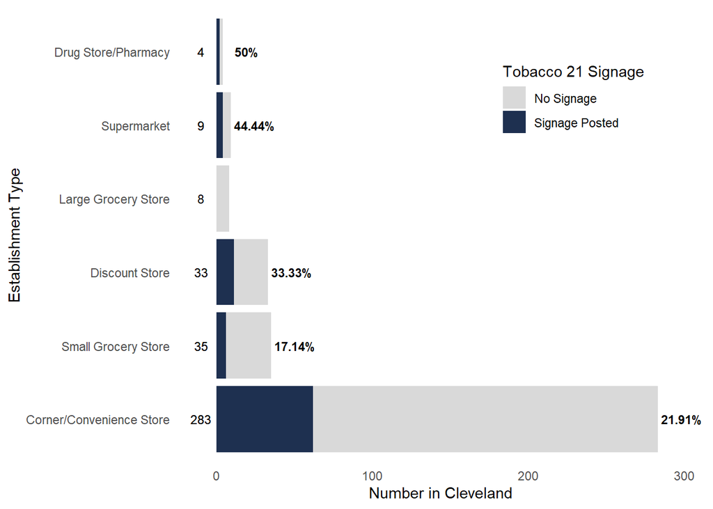

# Ad Coverage

We establish a baseline of information regarding which businesses are already in compliance with the new tobacco ordinance regarding ad coverage on windows and doors.

Using the data, we can determine the number of establishments that had more than 25% of their doors and windows covered by advertisements.

We established a new binary variable `ad25`, for which a value of 1 means that 25% or more of the windows and doors were covered by advertisements, while a value of 0 means that this was not the case.

Here, we summarized the presence of 25% or more coverage of ads, organized by establishment type, among those establishments that sold tobacco. We also calculated a proportion of those establishments that did not have more than 25% ad coverage among total stores of that type.

[output not shown]

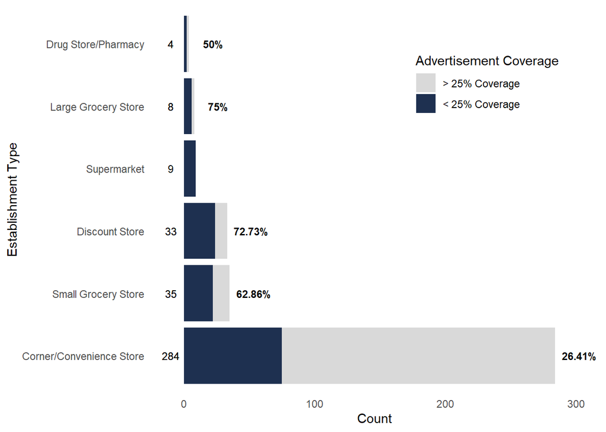

# Maps

As a small note about the maps that can be viewed at *https://tinyurl.com/CIFTR2025Map*, the information displayed comes directly from this data set. Given the street addresses of the establishments, a geocoder was used to calculate the latitude and longitude of each location for placement in GIS. Much of the information, including establishment type, whether or not the establishment sold tobacco or had t21 signage, more was calculated exactly as above before being geocoded.